# Entreprise Telco :

# Introduction

Le but de ce projet est de déterminer nos potentiels clients Churner. En effet, Telclo est une entreprise de télécomunication proposant un service téléphonique mais aussi d’autres services tels qu’ un accès a internet, un service de sauvegarde a disance , une protection des appareils, un support, et autres services… . Le but est de cibler nos clients futurs churners afin de potentiellment d’entamer des démarches afin de les reconquérir (offre promotionnelle,…) ou bien encore de déterminer les raisons de leurs départs afin d’établir peut-être une offre plus adaptée à certains clients. Il n’y a dans nos données pas de dimension temporelle. Nous avons pour ainsi dire pas de dates, on ne travaillera donc pas avec une dimension temporelle mais on aura à disposition l’ancienneté du contrat (“tenure”) qui nous sera particulièrement utile dans l’exercice. Par commodité et pour s’adapter aux contraintes imposées, nous augmenterons nos NA afin de pouvoir les remplacer, de plus nous avons transformé certaines variables catégorielles binaires en variables numériques.

Voici la liste des variables mises à disposition:

#### Customer ID : identifiant du client.

#### Gender : Sexe du client (M/F).

#### SeniorCitizen: Client est-il senior (1) ou non (0) ?

#### Partner : Le client a-t ‘il un partenaire (Yes) ou non (No)?

#### Dependents: Le client a-t ‘il des personnes à charge ou non ? (Yes, No)

#### Tenure : Nombre de mois que le client a passé dans la compagnie

#### PhoneService: Le client a-t ’il souscrit à un service téléphonique ? (Yes, No)

#### MultipleLines: Le client a-t’il plusieurs ligne ? (Yes, No, No phone service)

#### InternetService: A-t’il souscrit à un abonnement internet ? (DSL, Fiber optic, No)

#### OnlineSecurity: Le client a-t‘il souscrit au service de sécurité en ligne (Yes, No, No internet service)

#### OnlineBackup: Le client a-t‘il souscrit au service de sauvegarde en ligne (Yes, No, No internet service)

#### DeviceProtection: Le client a-t‘il souscrit au service de protection de l’appareil(Yes, No, No internet service)

#### TechSupport : Le client a-t‘il souscrit au service d’assistance ?(Yes, No, No internet service)

#### StreamingTV: Service de TV? (Yes, No, No internet service)

#### StreamingMovies: Service de film en streaming ?(Yes, No, No internet service)

#### Contract: Durée de vie du contrat (Month-to-month, One year, Two year)

#### PaperlessBilling: Facturation en papier (Yes, No)

#### PaymentMethod: Le type de paiement choisi (Electronic check, Mailed check, Bank transfer (automatic), Credit card (automatic))

#### MonthlyCharges: Le montant facturé mensuellement au client

#### TotalCharges: Le montant total facturé au client

#### Churn: Le client a-t’il quitté l’entreprise ? (Yes or No)

# Paramètrage des données

## Extraction de la table

```r
base=read.csv("Telco_projet.csv",header=TRUE, sep=",",na.strings= "")
head(base)
```

```
##   customerID gender SeniorCitizen Partner Dependents tenure PhoneService
## 1 7590-VHVEG Female             0     Yes         No      1           No
## 2 5575-GNVDE   Male             0      No         No     34          Yes
## 3 3668-QPYBK   Male             0      No         No      2          Yes
## 4 7795-CFOCW   Male             0      No         No     45           No
## 5 9237-HQITU Female             0      No         No      2          Yes
## 6 9305-CDSKC Female             0      No         No      8          Yes
##      MultipleLines InternetService OnlineSecurity OnlineBackup DeviceProtection
## 1 No phone service             DSL             No          Yes               No
## 2               No             DSL            Yes           No              Yes
## 3               No             DSL            Yes          Yes               No
## 4 No phone service             DSL            Yes           No              Yes
## 5               No     Fiber optic             No           No               No
## 6              Yes     Fiber optic             No           No              Yes
##   TechSupport StreamingTV StreamingMovies       Contract PaperlessBilling
## 1          No          No              No Month-to-month              Yes
## 2          No          No              No       One year               No
## 3          No          No              No Month-to-month              Yes
## 4         Yes          No              No       One year               No
## 5          No          No              No Month-to-month              Yes
## 6          No         Yes             Yes Month-to-month              Yes
##               PaymentMethod MonthlyCharges TotalCharges Churn
## 1          Electronic check          29.85        29.85    No
## 2              Mailed check          56.95      1889.50    No
## 3              Mailed check          53.85       108.15   Yes
## 4 Bank transfer (automatic)          42.30      1840.75    No
## 5          Electronic check          70.70       151.65   Yes
## 6          Electronic check          99.65       820.50   Yes
```

```r
str(base)
```

```
## 'data.frame':    7043 obs. of  21 variables:
##  $ customerID      : Factor w/ 7043 levels "0002-ORFBO","0003-MKNFE",..: 5376 3963 2565 5536 6512 6552 1003 4771 5605 4535 ...
##  $ gender          : Factor w/ 2 levels "Female","Male": 1 2 2 2 1 1 2 1 1 2 ...
##  $ SeniorCitizen   : int  0 0 0 0 0 0 0 0 0 0 ...
##  $ Partner         : Factor w/ 2 levels "No","Yes": 2 1 1 1 1 1 1 1 2 1 ...
##  $ Dependents      : Factor w/ 2 levels "No","Yes": 1 1 1 1 1 1 2 1 1 2 ...
##  $ tenure          : int  1 34 2 45 2 8 22 10 28 62 ...
##  $ PhoneService    : Factor w/ 2 levels "No","Yes": 1 2 2 1 2 2 2 1 2 2 ...
##  $ MultipleLines   : Factor w/ 3 levels "No","No phone service",..: 2 1 1 2 1 3 3 2 3 1 ...
##  $ InternetService : Factor w/ 3 levels "DSL","Fiber optic",..: 1 1 1 1 2 2 2 1 2 1 ...
##  $ OnlineSecurity  : Factor w/ 3 levels "No","No internet service",..: 1 3 3 3 1 1 1 3 1 3 ...
##  $ OnlineBackup    : Factor w/ 3 levels "No","No internet service",..: 3 1 3 1 1 1 3 1 1 3 ...
##  $ DeviceProtection: Factor w/ 3 levels "No","No internet service",..: 1 3 1 3 1 3 1 1 3 1 ...
##  $ TechSupport     : Factor w/ 3 levels "No","No internet service",..: 1 1 1 3 1 1 1 1 3 1 ...
##  $ StreamingTV     : Factor w/ 3 levels "No","No internet service",..: 1 1 1 1 1 3 3 1 3 1 ...
##  $ StreamingMovies : Factor w/ 3 levels "No","No internet service",..: 1 1 1 1 1 3 1 1 3 1 ...
##  $ Contract        : Factor w/ 3 levels "Month-to-month",..: 1 2 1 2 1 1 1 1 1 2 ...
##  $ PaperlessBilling: Factor w/ 2 levels "No","Yes": 2 1 2 1 2 2 2 1 2 1 ...
##  $ PaymentMethod   : Factor w/ 4 levels "Bank transfer (automatic)",..: 3 4 4 1 3 3 2 4 3 1 ...
##  $ MonthlyCharges  : num  29.9 57 53.9 42.3 70.7 ...
##  $ TotalCharges    : num  29.9 1889.5 108.2 1840.8 151.7 ...
##  $ Churn           : Factor w/ 2 levels "No","Yes": 1 1 2 1 2 2 1 1 2 1 ...
```

```r
summary(base)
```

```
##       customerID      gender     SeniorCitizen    Partner    Dependents
##  0002-ORFBO:   1   Female:3488   Min.   :0.0000   No :3641   No :4933
##  0003-MKNFE:   1   Male  :3555   1st Qu.:0.0000   Yes:3402   Yes:2110
##  0004-TLHLJ:   1                 Median :0.0000
##  0011-IGKFF:   1                 Mean   :0.1621
##  0013-EXCHZ:   1                 3rd Qu.:0.0000
##  0013-MHZWF:   1                 Max.   :1.0000
##  (Other)   :7037
##      tenure      PhoneService          MultipleLines     InternetService
##  Min.   : 0.00   No : 682     No              :3390   DSL        :2421
##  1st Qu.: 9.00   Yes:6361     No phone service: 682   Fiber optic:3096
##  Median :29.00                Yes             :2971   No         :1526
##  Mean   :32.37
##  3rd Qu.:55.00
##  Max.   :72.00
##
##              OnlineSecurity              OnlineBackup
##  No                 :3498   No                 :3088
##  No internet service:1526   No internet service:1526
##  Yes                :2019   Yes                :2429
##
##
##
##
##             DeviceProtection              TechSupport
##  No                 :3095    No                 :3473
##  No internet service:1526    No internet service:1526
##  Yes                :2422    Yes                :2044
##
##
##
##
##               StreamingTV              StreamingMovies           Contract
##  No                 :2810   No                 :2785   Month-to-month:3875
##  No internet service:1526   No internet service:1526   One year      :1473
##  Yes                :2707   Yes                :2732   Two year      :1695
##
##
##
##
##  PaperlessBilling                   PaymentMethod  MonthlyCharges
##  No :2872         Bank transfer (automatic):1544   Min.   : 18.25
##  Yes:4171         Credit card (automatic)  :1522   1st Qu.: 35.50
##                   Electronic check         :2365   Median : 70.35
##                   Mailed check             :1612   Mean   : 64.76
##                                                    3rd Qu.: 89.85
##                                                    Max.   :118.75
##
##   TotalCharges    Churn
##  Min.   :  18.8   No :5174
##  1st Qu.: 401.4   Yes:1869
##  Median :1397.5
##  Mean   :2283.3
##  3rd Qu.:3794.7
##  Max.   :8684.8
##  NA's   :11
```

## Transformation variable categorielle en numerique

```
## [1] "Female" "Male"
```

```
## [1] "No"  "Yes"
```

```
## [1] "No"  "Yes"
```

```
## [1] "No"  "Yes"
```

## Insertion des NA pour variables numériques

```r
insert_nas <- function(x) {
  len <- length(x)
  n<- sample(1:floor(0.1*len),1)
  i <- sample(1:len,n)
  x[i] <- NA
  x
}

base[,c('TotalCharges','PaperlessBilling')] <- data.frame(sapply(base[,c('TotalCharges','PaperlessBilling')], insert_nas))
```

## Insertion des NA pour variables qualitatives

```r
base[,c('StreamingMovies','Contract')] <- data.frame(sapply(base[,c('StreamingMovies','Contract')], insert_nas))
```

# Churner , Churner ! Qui-est-tu ?

## Analyse graphique univariée

### Proportion de la variable cible

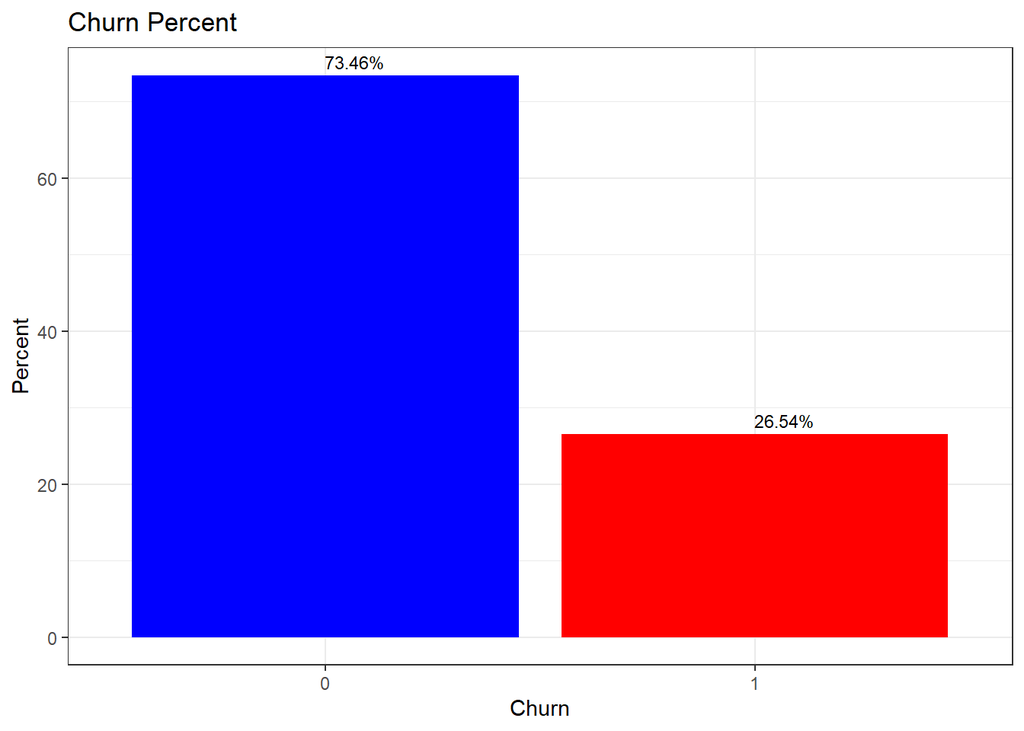

```r
table <- base
options(repr.plot.width = 6, repr.plot.height = 4)
table %>%
  group_by(Churn) %>%
  summarise(Count = n())%>%
  mutate(percent = prop.table(Count)*100)%>%
  ggplot(aes(reorder(Churn, -percent), percent), fill = Churn)+
  geom_col(fill = c("blue", "red"))+
  geom_text(aes(label = sprintf("%.2f%%", percent)), hjust = 0.01,vjust = -0.5, size =3)+
  theme_bw()+
  xlab("Churn") +
  ylab("Percent")+
  ggtitle("Churn Percent")
```

On peut observer ici la répartition de Churner dans notre population. On voit ainsi qu’on possède plus d’un quart de churner contre trois quart de non churners. On peut donc ici appliquer nos algorithmes assez serainement car il n’y a pas d’oversampling (= trop petite repréentation de la variable ciblée).

### Représentation graphique des variables avec NA

```r
numerik <- Filter(is.numeric,table)
karacter <- Filter(is.factor,table)
karacter$'customerID' =NULL
#describe(karacter)
```

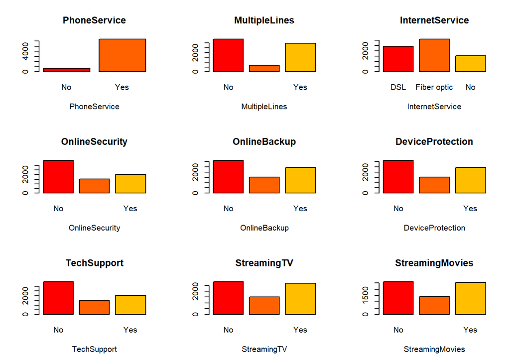

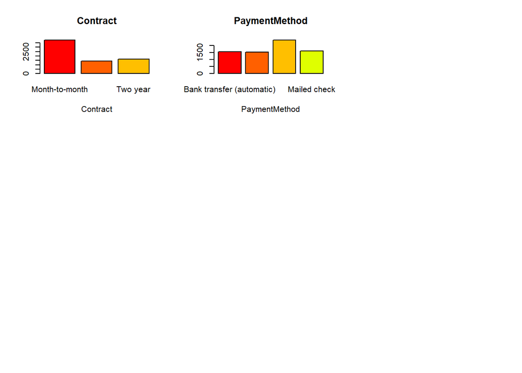

```r
#Graph variable catégorielle
par(mfrow=c(3,3))
for(x in seq(1,length(karacter)))plot(karacter[,x], xlab=names(karacter[x]),
                                   col=rainbow(16),
                                   main=names(karacter[x]), horiz=F)
```

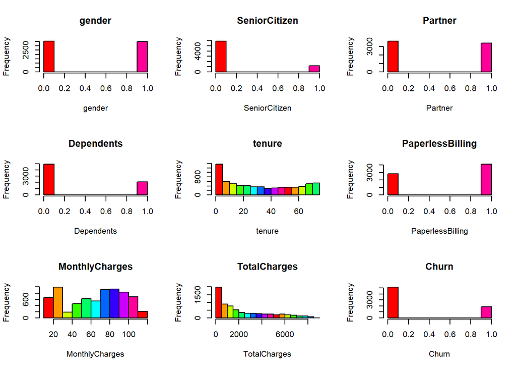

```r
#Graph variable numérique
par(mfrow=c(3,3))#Pour mettre les 6 histos... sur le meme graph
for(x in seq(1, length(numerik)))hist(numerik[,x], xlab=names(numerik[x]),
                                   col=rainbow(10), main=names(numerik[x]))
```

## Analyse graphique multivariée

### Diagramme alluvial

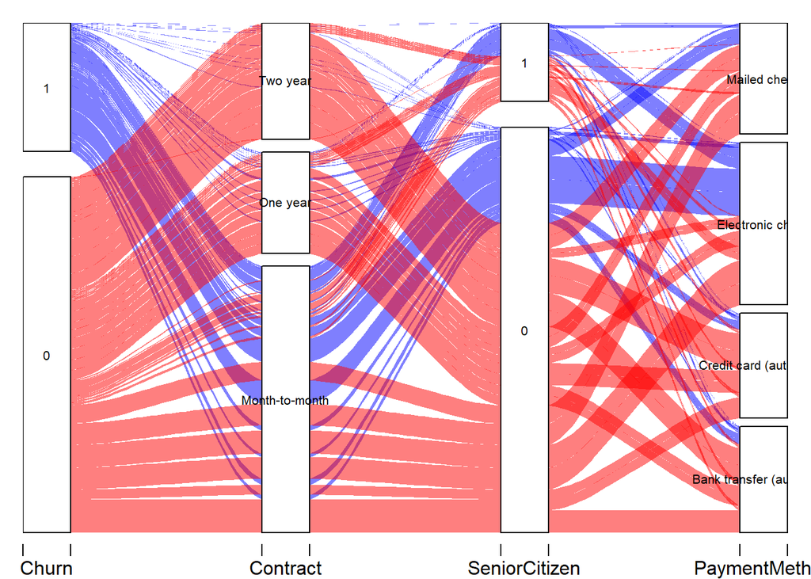

```r
par(mfrow=c(1,1))
table2 <- table %>%

  group_by(Churn, Contract, SeniorCitizen, PaymentMethod, gender ) %>%

  summarise(N = n()) %>%

  ungroup %>%

  na.omit
alluvial(table2[, c(1:4)],

         freq=table2$N, border=NA,

         col=ifelse(table2$Churn == "1", "blue", "red"),

         cex=0.65,

         ordering = list(

           order(table2$Churn, table2$SeniorCitizen=="Yes"),

           order(table2$gender, table2$SeniorCitizen=="Yes"),

           NULL,

           NULL))
```

Le graphique alluvial permet de voir certaines interactions ou profil type du caractère ciblé. On voit ici un chemin qui se dessine pour un Churner. Ici, nous pouvons voir qu’un Churner aura plus de chances d’avoir un contrat month-to-month, qu’il ne sera pas senior et qu’il paiera plutôt par ‘electronic check’. Cependant, avec ce genre de graph, il faut s’assurer de l’indépendance de chacune des variables utilisées. En effet, on pourrait se demander si un Churn, qui est visiblement majoritairement en contrat mois/mois n’a pas pour seul choix le paiement par ‘electronic check’. Il faudra donc vérifier cela afin de pouvoir conjecturer sur une potentielle causalité.

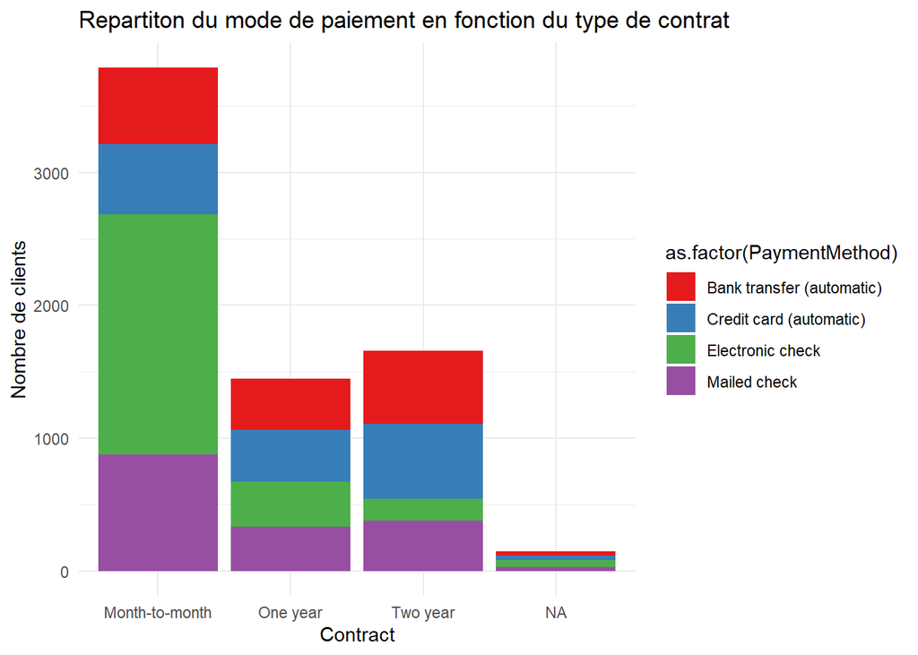

```r
ggplot(table) +
  geom_bar(aes(x=Contract,fill=as.factor(PaymentMethod)))+
  ylab("Nombre de clients") +
  ggtitle("Repartiton du mode de paiement en fonction du type de contrat") +
  scale_fill_brewer(palette="Set1") +
  theme_minimal()
```

### Représentation de la part de Churn en fonction de la durée du contrat

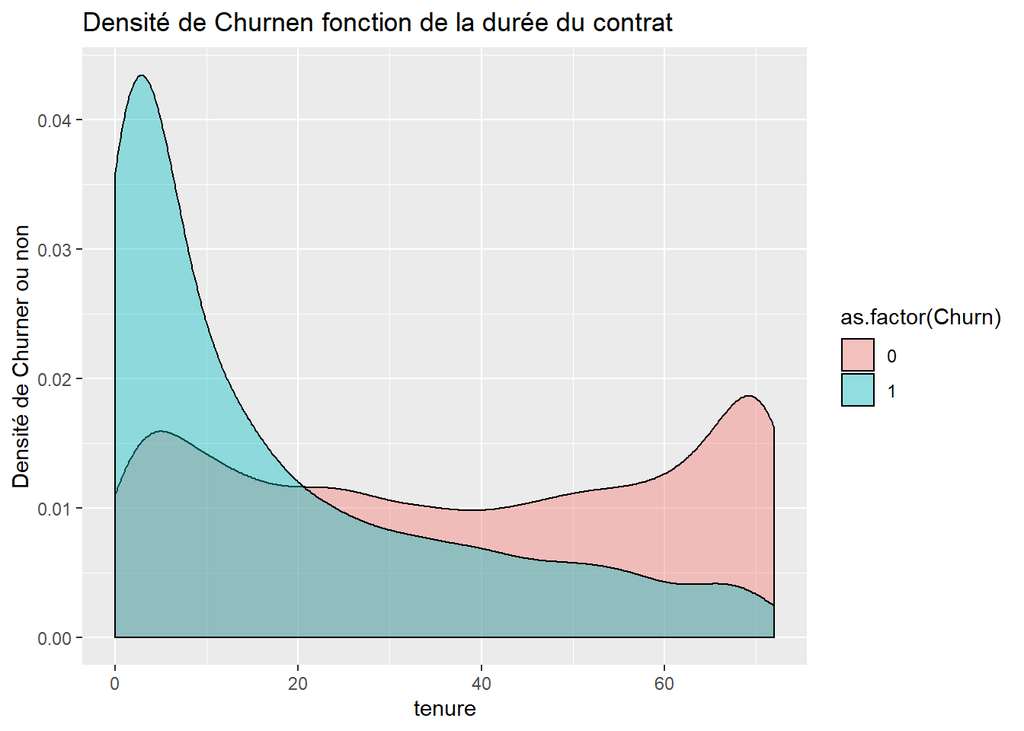

```r
ggplot(table) +
  geom_density(aes(x=tenure,fill=as.factor(Churn)),alpha=0.4)+

  ggtitle("Densité de Churnen fonction de la durée du contrat ")+
  ylab("Densité de Churner ou non")
```

### Représentation des sommes payées en fonction du Churn

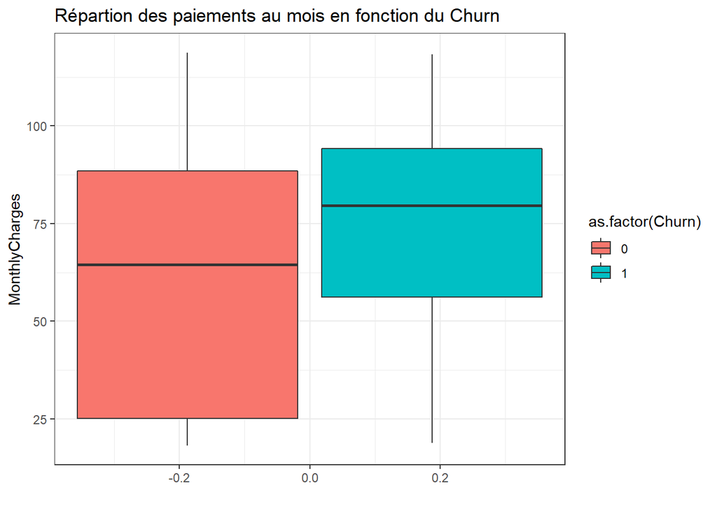

```r
ggplot(table, aes(y= MonthlyCharges,  fill = as.factor(Churn))) +
geom_boxplot()+
theme_bw()+
ggtitle("Répartion des paiements au mois en fonction du Churn")+
xlab(" ")
```

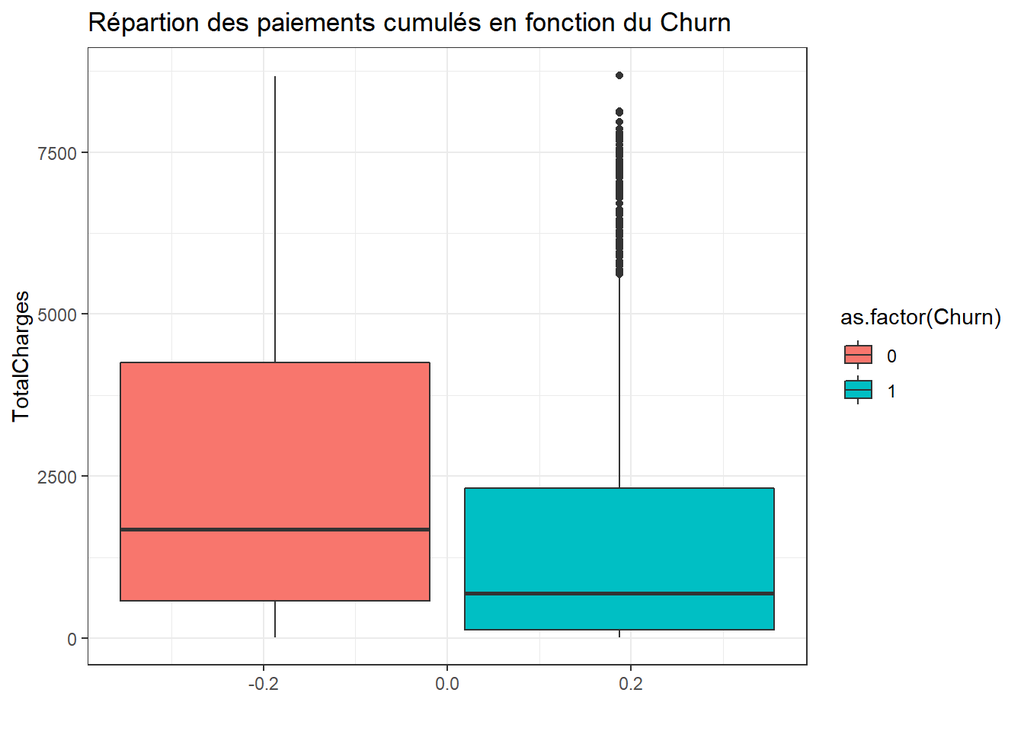

```r
ggplot(table, aes(y= TotalCharges,  fill = as.factor(Churn))) +
geom_boxplot()+
theme_bw()+
ggtitle("Répartion des paiements cumulés en fonction du Churn")+
xlab(" ")
```

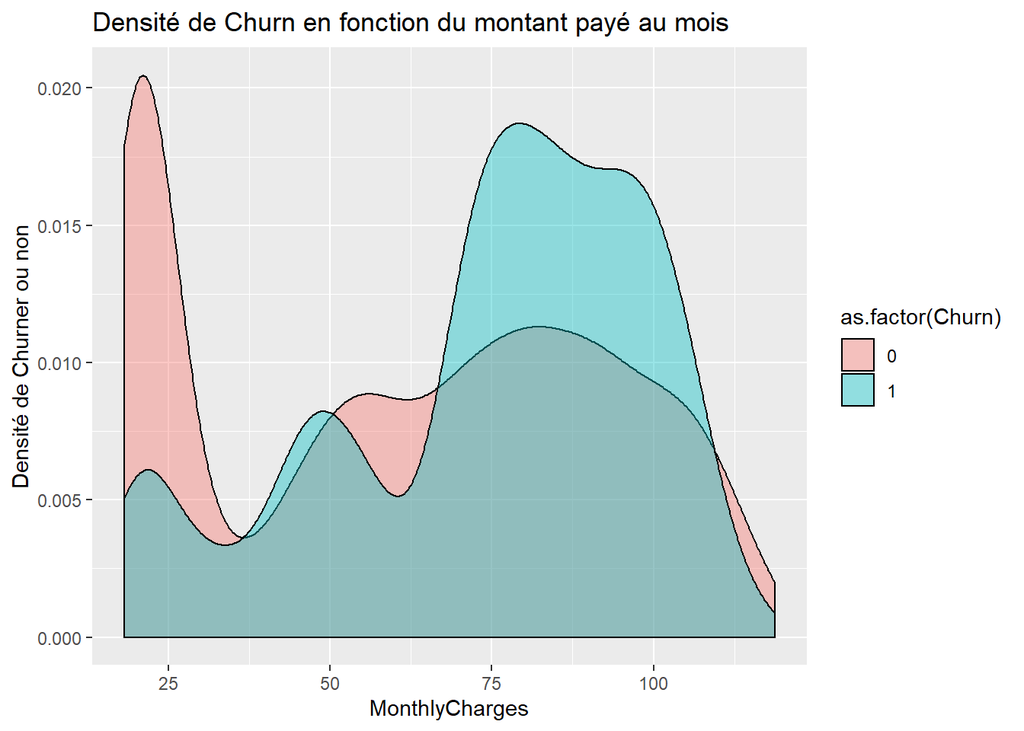

```r
ggplot(table) +
  geom_density(aes(x=MonthlyCharges,fill=as.factor(Churn)),alpha=0.4)+

  ggtitle("Densité de Churn en fonction du montant payé au mois ")+
  ylab("Densité de Churner ou non")
```

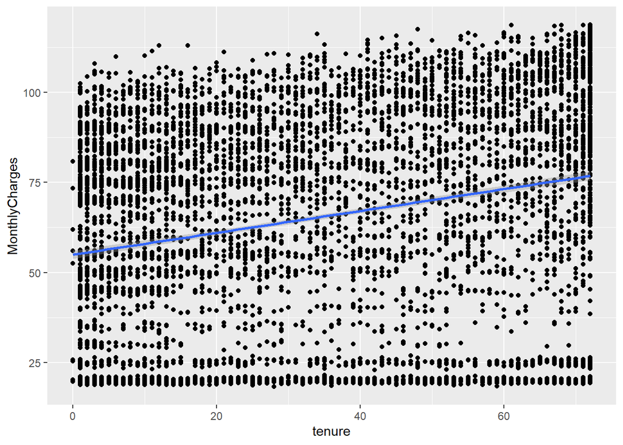

```r
ggplot(data = table, aes(x = tenure, y =MonthlyCharges )) + geom_point() + geom_smooth(method = "lm")
```

### Représentation du Churn en fonction du type de contrat par sexe

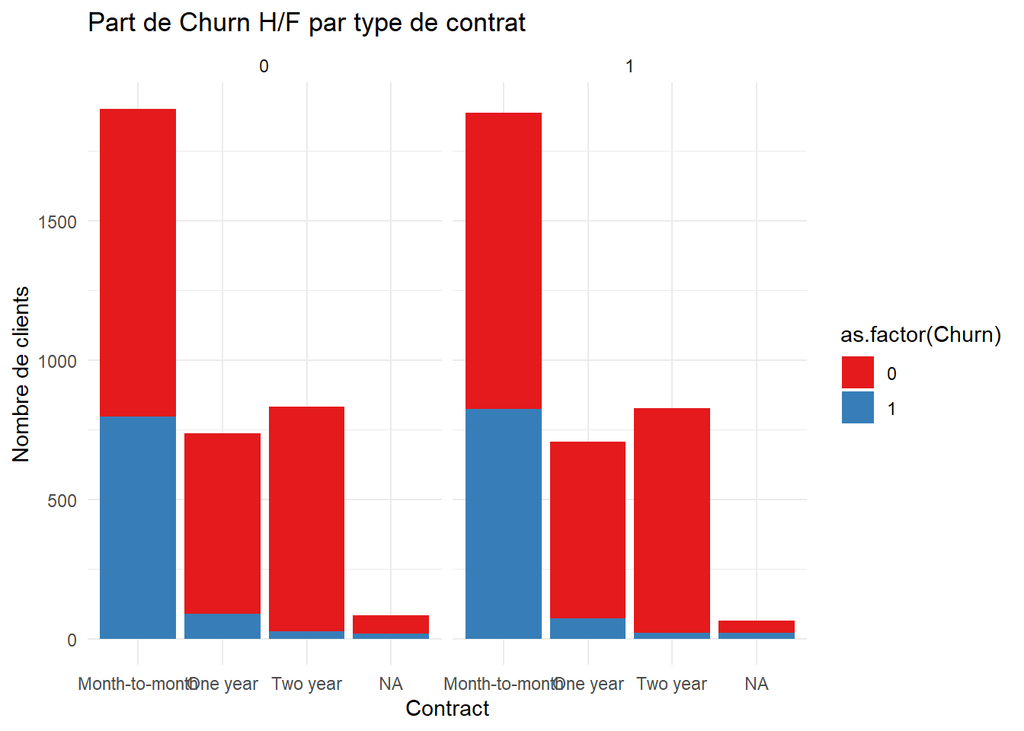

```r
ggplot(table) +
  geom_bar(aes(x=Contract,fill=as.factor(Churn)))+
  facet_wrap(~gender, ncol = 2, nrow = 1)+

  ylab("Nombre de clients") +

  ggtitle("Part de Churn H/F par type de contrat") +

  scale_fill_brewer(palette="Set1") +

  theme_minimal()
```

Nous pouvons voir ici que le type de contrat a une importance déterminante dans le Churn. En effet, l’offre de contrat mois/mois entraîne un fort Churn ce qui tend a rejoindre l’analyse du premier graph alluvial. Cependant cette analyse est a modérée, car cette offre est peut-être destinée à des clients considérés comme fragile qui ne seraient peut être pas client chez Telco avec d’autres offres de contrat long terme.

### Représentation du Churn en densité en fonction de la durée du contrat

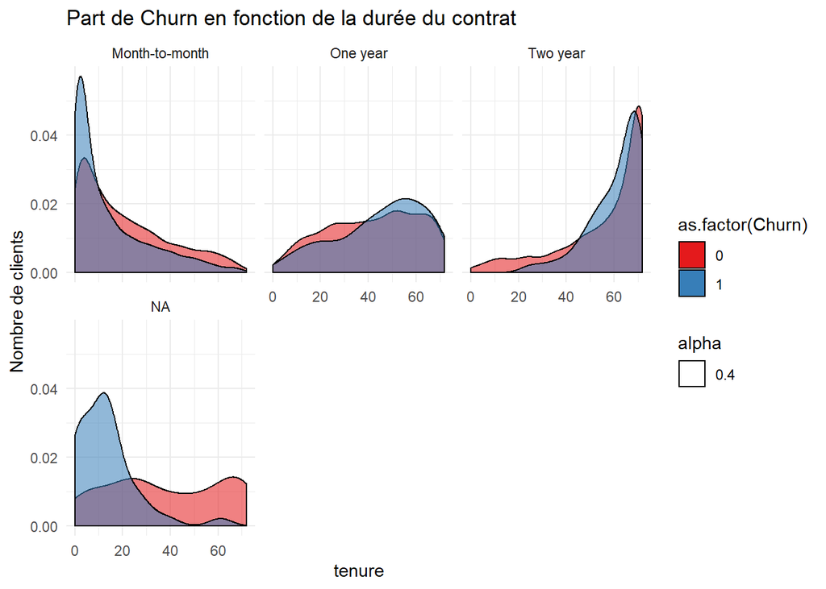

```r
ggplot(table) +
  geom_density(aes(x=tenure,fill=as.factor(Churn), alpha=0.4))+

  facet_wrap(~Contract, ncol = 3)+

  ylab("Nombre de clients") +

  ggtitle("Part de Churn en fonction de la durée du contrat") +

  scale_fill_brewer(palette="Set1") +

  theme_minimal()
```

Dans la logique des choses, nous pouvons voir que la population churn en fonction de l’anciennté du contrat pour les contrat long terme (1 an & 2 ans) cependant dans le cas du contrat “month to month”, nous voyons un pic de Churn dès les premiers joursq du début du contrat. C’est une situation quji se remarque souvent dans les études de Churn, en effet, le client peut parfois changer d’avis dans les premiers jours de la signature du contrat et se rétracter (avec remboursement ou non). Cependant, cela peut-être aussi du a une mauvaise segmentation de notre offre et de client ayant besoin d’un abonnement téléphonique inférieur à un mois. Peut-être qu’avec une offre de contrat d’une semaine ou journalière, on pourrait capter plus de client qui ne veulent pas aujourd’hui payer un mois inutilement.

### Quelle est l’importance de la détention de plusieurs lignes

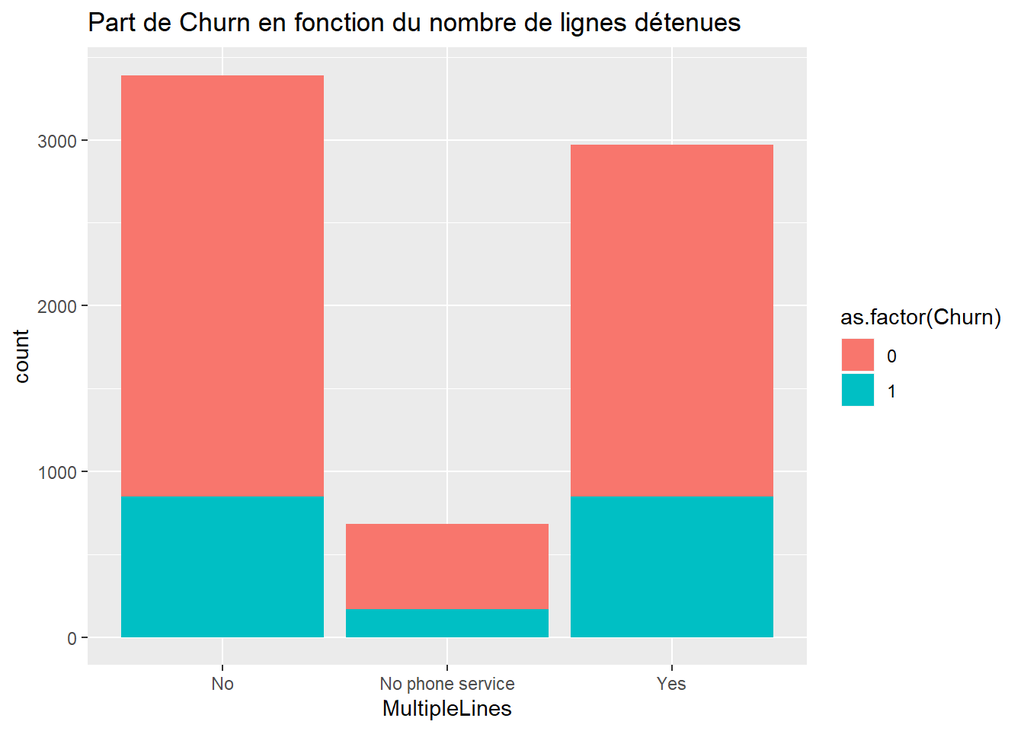

```r
ggplot(table) +
  geom_bar(aes(x=MultipleLines,fill=as.factor(Churn)))+
  ggtitle("Part de Churn en fonction du nombre de lignes détenues")
```

Sur ce graphique, nous constatons qu’il n’y a pas de relation déterminante entre le fait de posséder un abonnement telephonique (simple ou multilignes) dans le churn

### Quelle est l’importance du Churn en fonction du nombre de service souscrit ?

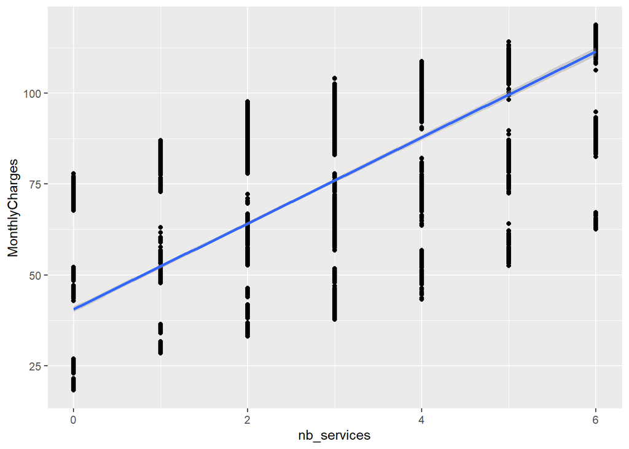

```r
services <- table
services$OnlineSecurity <- ifelse(services$OnlineSecurity == 'Yes',1,0)
services$OnlineBackup <- ifelse(services$OnlineBackup == 'No' | services$OnlineBackup =='No internet service',0,1)
services$DeviceProtection <- ifelse(services$DeviceProtection == 'No' | services$DeviceProtection =='No internet service',0,1)
services$TechSupport <- ifelse(services$TechSupport == 'No' | services$TechSupport =='No internet service',0,1)
services$StreamingTV <- ifelse(services$StreamingTV == 'No' | services$StreamingTV =='No internet service',0,1)
services$StreamingMovies <- ifelse(services$StreamingMovies == 'No' | services$StreamingMovies =='No internet service',0,1)
#services$InternetService <- ifelse(services$InternetService == 'No' ,0,1)
services$nb_services = services$OnlineSecurity + services$OnlineBackup + services$DeviceProtection + services$TechSupport + services$StreamingTV + services$StreamingMovies
table$nb_services <- services$nb_services

ggplot(data = table, aes(x = nb_services, y =MonthlyCharges )) + geom_point() + geom_smooth(method = "lm")
```

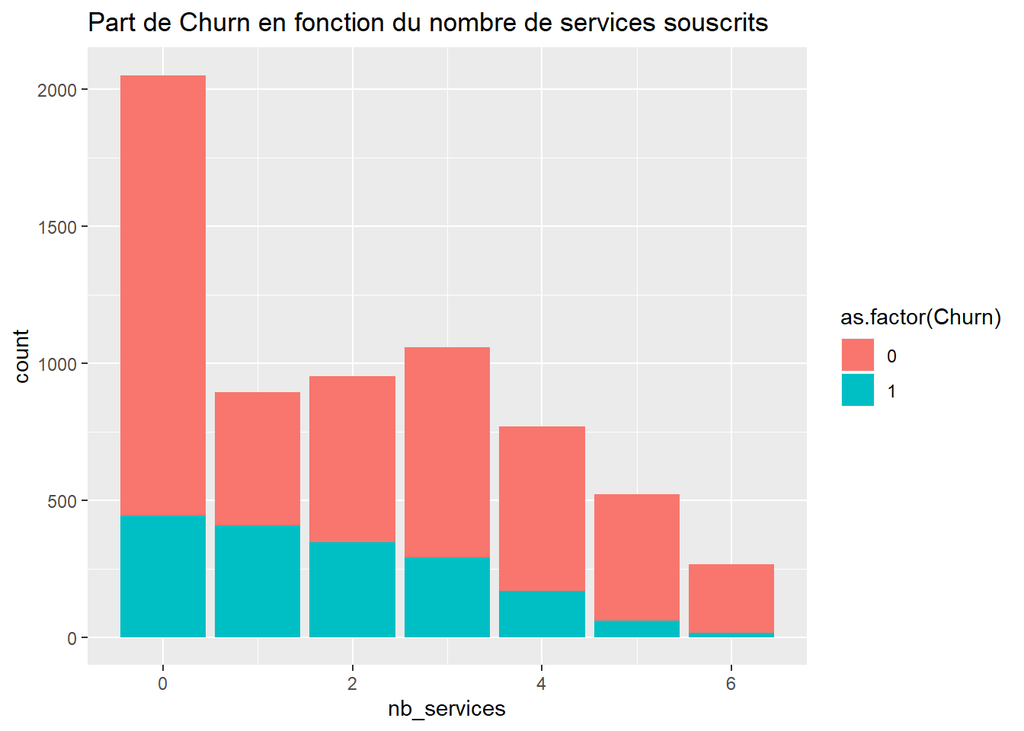

```r
ggplot(services) +
  geom_bar(aes(x=nb_services,fill=as.factor(Churn)))+
  ggtitle("Part de Churn en fonction du nombre de services souscrits")
```

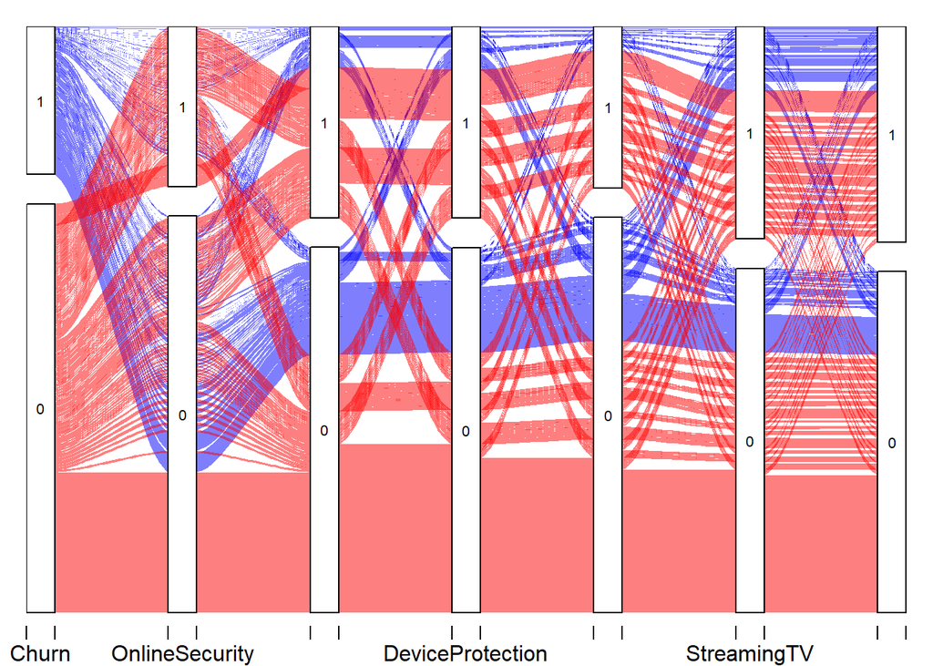

```r
table3 <- services %>%

  group_by(Churn, OnlineSecurity, OnlineBackup, DeviceProtection, TechSupport, StreamingTV, StreamingMovies,gender ) %>%

  summarise(N = n()) %>%

  ungroup %>%

  na.omit

alluvial(table3[, c(1:7)],

         freq=table3$N, border=NA,

         col=ifelse(table3$Churn == "1", "blue", "red"),

         cex=0.65,

         ordering = list(

           order(table3$Churn, table3$OnlineSecurity==1),

           order(table3$gender, table3$OnlineSecurity=="Yes"),

           NULL,
           NULL,
           NULL,
           NULL,

           NULL))
```

### Remplacement des valeurs manquantes

```r
sum(is.na(table))
```

```
## [1] 1331
```

On décide de remplacer les valeurs manquantes par la méthode KNN qui nous permet ici la plus adéquat à la vue du peu d’observation dont nous disposons. Le remplacement par 0 aurait été inadéquat car on aurait eu des sommes payées égales à 0. De même, le remplacement par la moyenne ou la médiane aurait pû être aussi judicieux mais moins intéressant que les kNN qui suit

```r
set.seed(496)
#NOMBRE DE NA
navarspl=colSums(is.na(table))/nrow(table) #valeur manquante
#navarspl
tab.kNN=kNN(table[,-21], k=10, imp_var=F)#peut etre long k=5 est le nombre de voisin qu il va regarder pour calculer la dist
#nume.kNN
summary(tab.kNN)
```

```
##       customerID       gender       SeniorCitizen       Partner
##  0002-ORFBO:   1   Min.   :0.0000   Min.   :0.0000   Min.   :0.000
##  0003-MKNFE:   1   1st Qu.:0.0000   1st Qu.:0.0000   1st Qu.:0.000
##  0004-TLHLJ:   1   Median :0.0000   Median :0.0000   Median :0.000
##  0011-IGKFF:   1   Mean   :0.4952   Mean   :0.1621   Mean   :0.483
##  0013-EXCHZ:   1   3rd Qu.:1.0000   3rd Qu.:0.0000   3rd Qu.:1.000
##  0013-MHZWF:   1   Max.   :1.0000   Max.   :1.0000   Max.   :1.000
##  (Other)   :7037
##    Dependents         tenure      PhoneService          MultipleLines
##  Min.   :0.0000   Min.   : 0.00   No : 682     No              :3390
##  1st Qu.:0.0000   1st Qu.: 9.00   Yes:6361     No phone service: 682
##  Median :0.0000   Median :29.00                Yes             :2971
##  Mean   :0.2996   Mean   :32.37
##  3rd Qu.:1.0000   3rd Qu.:55.00
##  Max.   :1.0000   Max.   :72.00
##
##     InternetService             OnlineSecurity              OnlineBackup
##  DSL        :2421   No                 :3498   No                 :3088
##  Fiber optic:3096   No internet service:1526   No internet service:1526
##  No         :1526   Yes                :2019   Yes                :2429
##
##
##
##
##             DeviceProtection              TechSupport
##  No                 :3095    No                 :3473
##  No internet service:1526    No internet service:1526
##  Yes                :2422    Yes                :2044
##
##
##
##
##               StreamingTV              StreamingMovies           Contract
##  No                 :2810   No                 :2680   Month-to-month:3893
##  No internet service:1526   No internet service:1512   One year      :1459
##  Yes                :2707   Yes                :2851   Two year      :1691
##
##
##
##
##  PaperlessBilling                   PaymentMethod  MonthlyCharges
##  Min.   :0.0000   Bank transfer (automatic):1544   Min.   : 18.25
##  1st Qu.:0.0000   Credit card (automatic)  :1522   1st Qu.: 35.50
##  Median :1.0000   Electronic check         :2365   Median : 70.35
##  Mean   :0.5934   Mailed check             :1612   Mean   : 64.76
##  3rd Qu.:1.0000                                    3rd Qu.: 89.85
##  Max.   :1.0000                                    Max.   :118.75
##
##   TotalCharges     nb_services
##  Min.   :  18.8   Min.   :0.000
##  1st Qu.: 401.4   1st Qu.:0.000
##  Median :1396.9   Median :2.000
##  Mean   :2281.3   Mean   :2.036
##  3rd Qu.:3783.2   3rd Qu.:3.000
##  Max.   :8684.8   Max.   :6.000
##
```

```r
tab.kNN$Churn <- table$Churn
```

N.B : Etant donné l’aspect prédictif de l’algorithme kNN nous avons enlever la variables Churn pour éviter de biaiser notre modèle.

```r
nume.kNN <- Filter(is.numeric,tab.kNN)
kar.kNN <- Filter(is.factor,tab.kNN)
kar.kNN$'customerID' =NULL
#describe(karacter)
```

# Etude des intéractions de variables

## Variables numériques

### Etude de corrélation

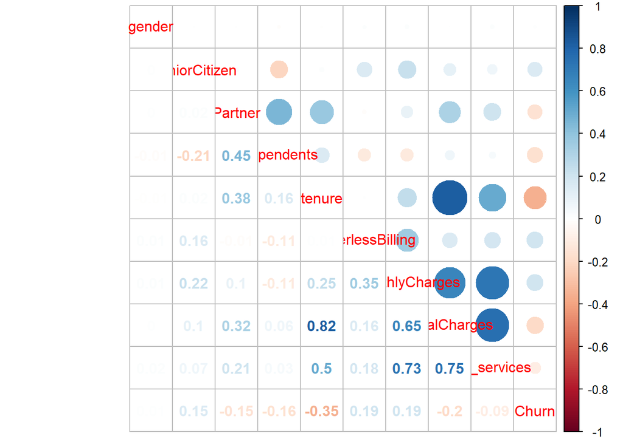

```r
#Analyse corrélation variable numériques
par(mfrow=c(1,1))
M <- cor(nume.kNN)
corrplot.mixed(M)
```

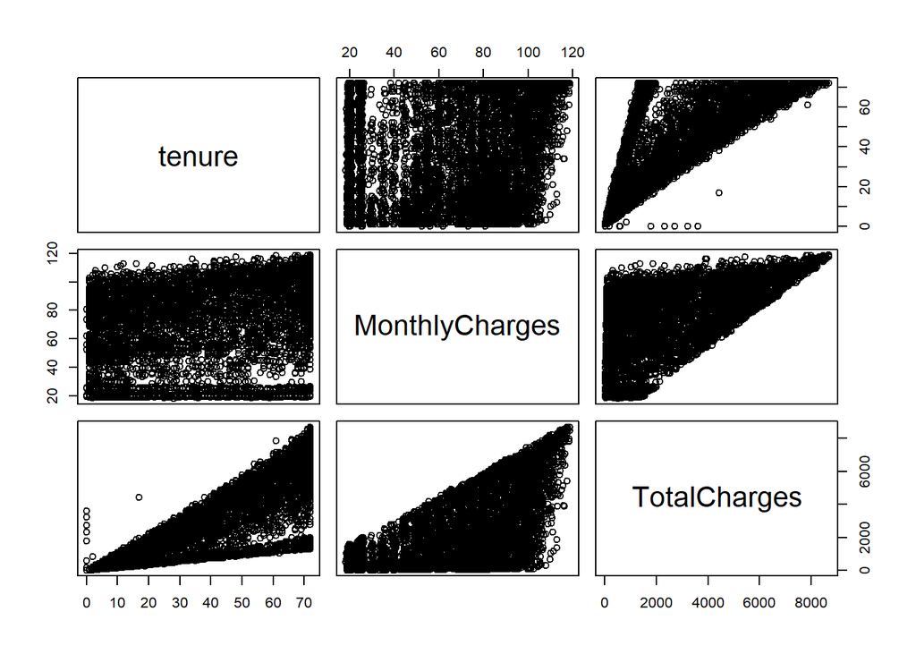

```r
pairs(nume.kNN[, c("tenure", "MonthlyCharges", "TotalCharges")])
```

Nous étudions ici les interactions entre les variables numériques. Nous pouvons voir sur notre matrice de corrélation, de forts lien entre certaines variables. Nous pouvons citer notamment les corrélations entre TotalCharges et tenure , TotalCharges et MonthlyCharges. Nous povons dès lors soupçonner la présence de colinéarité entre ces variables afin de connaître la force du lien, pour savoir si leur lien peut-être négatif dans notre modèle.

Sur le graphique “pairs”, nous avons mis en relation nos variables corrélées afin de connaître leurs répartitions. Nous pouvons y voir l’effet croissant de l’ancienneté sur le montant total de charge ce qui est logique mais nous pouvons voir aussi l’effet croissant des charges mensuelles sur le montant total de charges, ce qui n’est pas intéressant il s’agit d’une même information.

### Analyse Composantes principales (ACP)

```r
res.pca <- PCA(nume.kNN, quanti.sup=c(9),  graph = FALSE)
#Valeurs propres et axes
eig.val <- get_eigenvalue(res.pca)
eig.val
```

```
##       eigenvalue variance.percent cumulative.variance.percent
## Dim.1 2.49191602       27.6879558                    27.68796
## Dim.2 1.86072148       20.6746831                    48.36264
## Dim.3 1.07457121       11.9396802                    60.30232
## Dim.4 0.99952243       11.1058048                    71.40812
## Dim.5 0.87959974        9.7733304                    81.18145
## Dim.6 0.72142326        8.0158140                    89.19727
## Dim.7 0.48337084        5.3707871                    94.56806
## Dim.8 0.42934105        4.7704561                    99.33851
## Dim.9 0.05953396        0.6614885                   100.00000
```

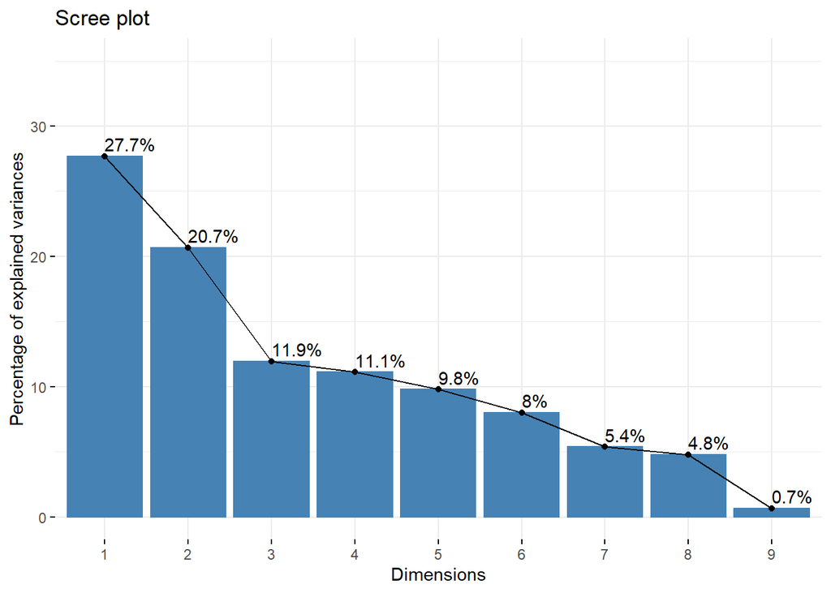

```r
#Graphique
fviz_eig(res.pca, addlabels = TRUE, ylim = c(0, 35))
```

```r
#Extraction des r?sultats (variables)
var <- get_pca_var(res.pca)
var
```

```
## Principal Component Analysis Results for variables
##  ===================================================
##   Name       Description
## 1 "$coord"   "Coordinates for the variables"
## 2 "$cor"     "Correlations between variables and dimensions"
## 3 "$cos2"    "Cos2 for the variables"
## 4 "$contrib" "contributions of the variables"
```

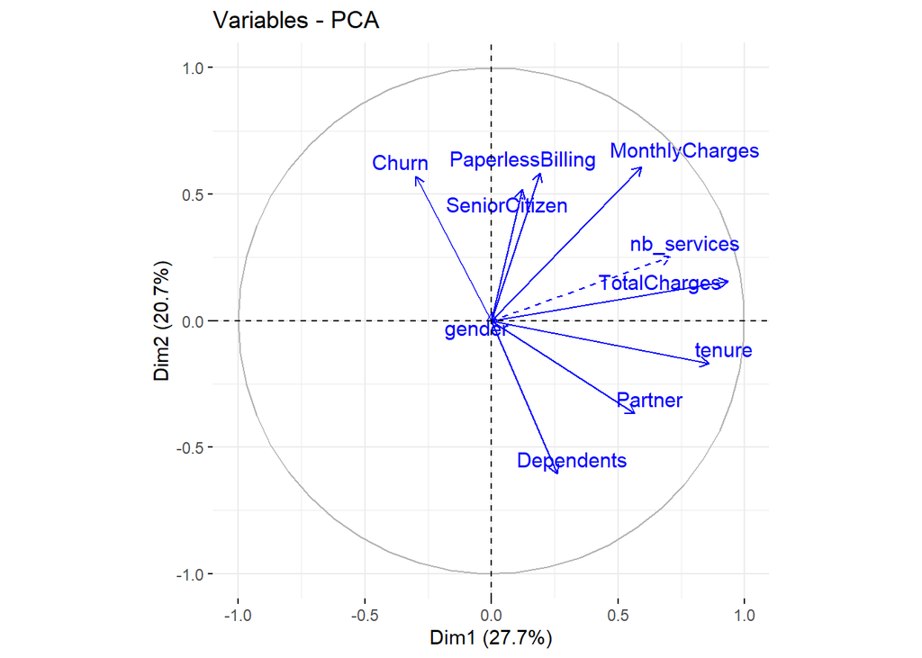

```r
#Cercle de correlation
fviz_pca_var(res.pca, col.var ="blue", repel = TRUE)
```

```r
#Contribution des variables
var$contrib
```

```
##                         Dim.1       Dim.2      Dim.3        Dim.4       Dim.5
## gender            0.000151801  0.05838906  0.4510149 99.282957457  0.18115848
## SeniorCitizen     0.581863077 14.45302915  0.0283593  0.257454079 74.94371092
## Partner          12.849870196  7.18400877 23.8629911  0.078724067  7.26987470
## Dependents        2.718679787 19.65576420 32.9444771  0.125792994  0.08439997
## tenure           29.653262352  1.53502152  6.5981806  0.021817618  0.01015740
## PaperlessBilling  1.480808911 18.32375300  9.3082933  0.027145859 12.69744876
## MonthlyCharges   14.067634129 19.93063320  0.6076679  0.001372235  3.56192319
## TotalCharges     35.047790459  1.30322755  3.2488964  0.008622150  0.99175051
## Churn             3.599939288 17.55617356 22.9501194  0.196113541  0.25957607
```

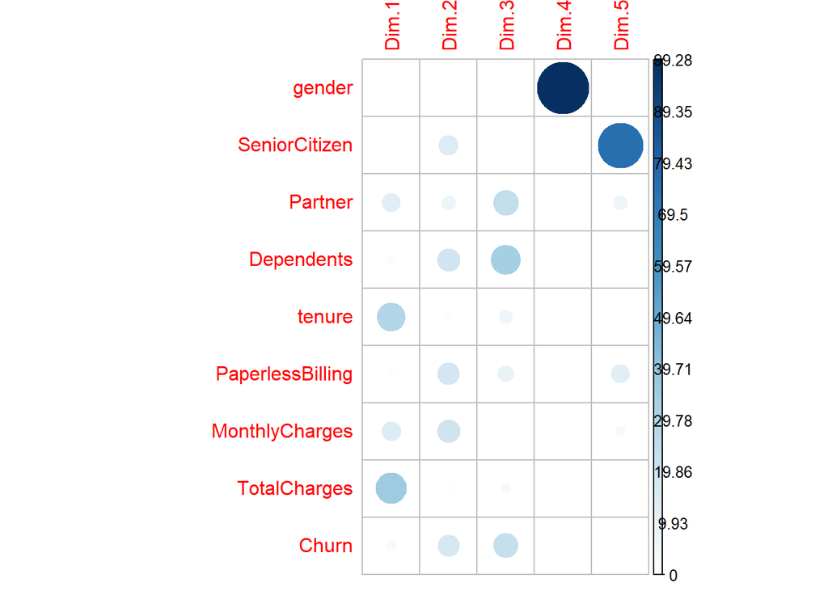

```r
corrplot(var$contrib, is.corr=FALSE)
```

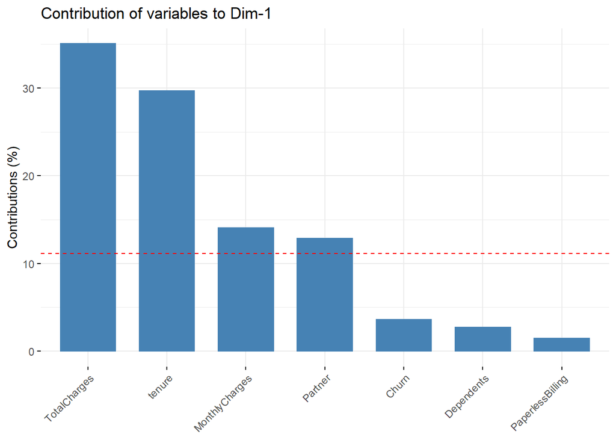

```r
fviz_contrib(res.pca, choice = "var", axes = 1, top = 7)  #histo par axe
```

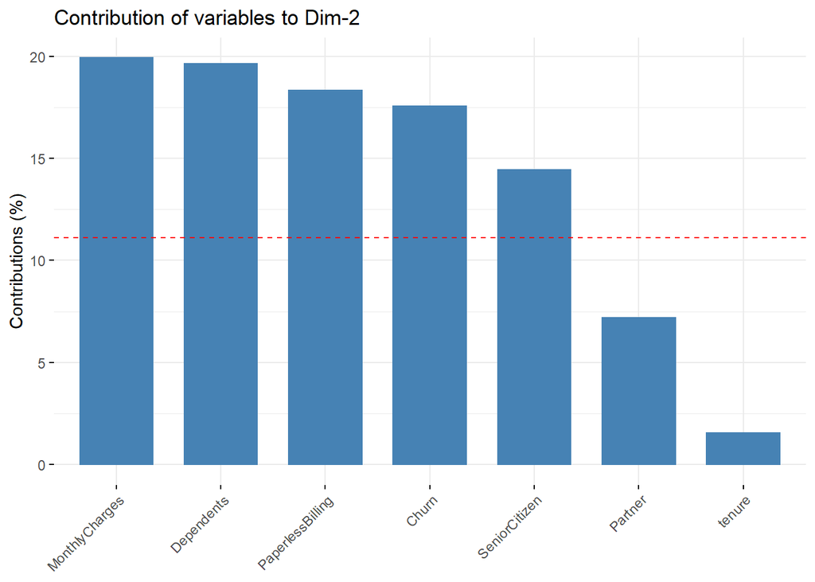

```r
fviz_contrib(res.pca, choice = "var", axes = 2, top = 7)
```

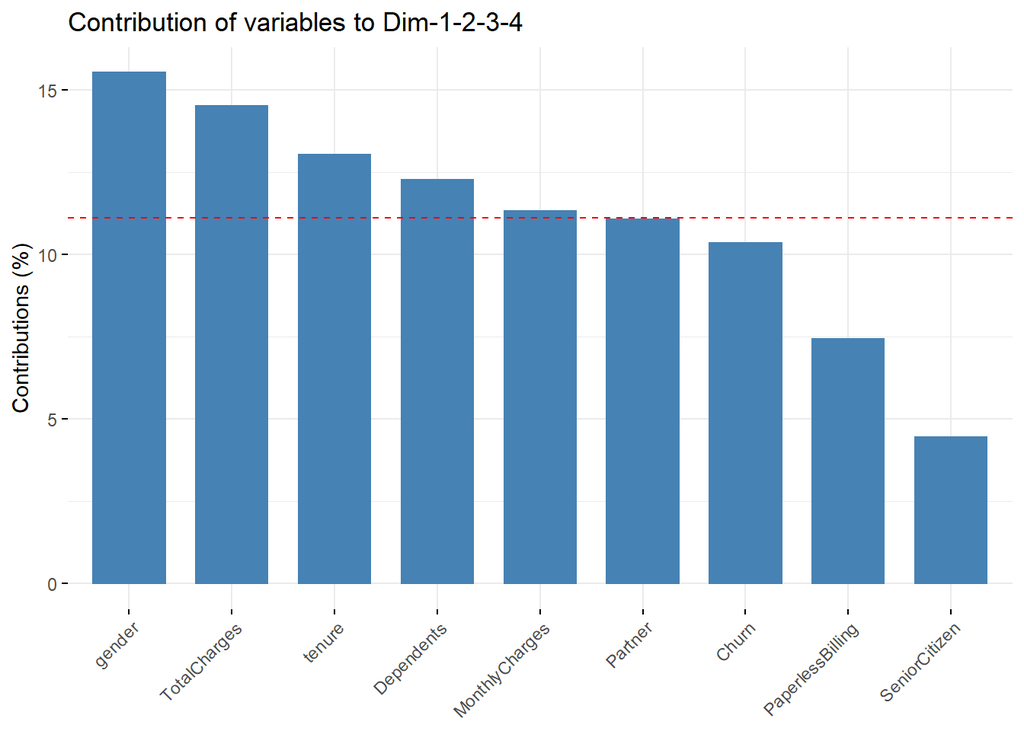

```r
fviz_contrib(res.pca, choice = "var", axes = 1:4, top = 10) #les 3 axes cumul?s
```

Graphiques de contribution: Les deux graphiques ci-dessus confirme les observations effectuées plus haut, sur le cercle de corrélation et la matrice de corrélation des variables aux dimensions.

### Etude de la colinéarité

Au sens strict, on parle de multicolinéarité parfaite lorsqu’une des variables explicatives d’un modèle est une combinaison linéraire d’une ou plusieurs autres variables explicatives introduites dans le même modèle. L’absence de multicolinéarité parfaite est une des conditions requises pour pouvoir estimer un modèle linéaire et, par extension, un modèle linéaire généralisé (dont les modèles de régression logistique).La multicolinéarité n’a aucune incidence sur l’adéquation de l’ajustement, ni sur la qualité de la prévision. Cependant, les coefficients individuels associés à chaque variable explicative ne peuvent pas être interprétés de façon fiable. c’est pour cela qu’il nous est nécessaire de la traiter.

```r
reg <- glm(Churn ~ ., data = nume.kNN, family= binomial())
print(summary(reg))
```

```
##
## Call:
## glm(formula = Churn ~ ., family = binomial(), data = nume.kNN)
##
## Deviance Residuals:
##     Min       1Q   Median       3Q      Max
## -1.8697  -0.6927  -0.3731   0.7150   3.0907
##
## Coefficients:
##                    Estimate Std. Error z value Pr(>|z|)
## (Intercept)      -1.869e+00  1.260e-01 -14.838  < 2e-16 ***
## gender            1.473e-02  6.322e-02   0.233 0.815824
## SeniorCitizen     4.268e-01  8.290e-02   5.148 2.63e-07 ***
## Partner           2.716e-02  7.584e-02   0.358 0.720279
## Dependents       -2.954e-01  8.681e-02  -3.403 0.000667 ***
## tenure           -6.230e-02  5.347e-03 -11.651  < 2e-16 ***
## PaperlessBilling  5.358e-01  7.182e-02   7.460 8.64e-14 ***
## MonthlyCharges    3.338e-02  1.980e-03  16.862  < 2e-16 ***
## TotalCharges      2.108e-04  6.131e-05   3.439 0.000584 ***
## nb_services      -2.969e-01  3.162e-02  -9.388  < 2e-16 ***
## ---
## Signif. codes:  0 '***' 0.001 '**' 0.01 '*' 0.05 '.' 0.1 ' ' 1
##
## (Dispersion parameter for binomial family taken to be 1)
##
##     Null deviance: 8150.1  on 7042  degrees of freedom
## Residual deviance: 6146.6  on 7033  degrees of freedom
## AIC: 6166.6
##
## Number of Fisher Scoring iterations: 6
```

```r
print(vif(reg))
```

```
##           gender    SeniorCitizen          Partner       Dependents
##         1.001268         1.115230         1.382332         1.290524
##           tenure PaperlessBilling   MonthlyCharges     TotalCharges
##        12.725115         1.108372         2.976800        16.998788
##      nb_services
##         2.667144
```

```r
# Make predictions
predictions <- reg %>% predict(nume.kNN)
# Model performance
data.frame(
  RMSE = RMSE(predictions, nume.kNN$Churn),
  R2 = R2(predictions, nume.kNN$Churn)
)
```

```
##       RMSE        R2
## 1 2.315238 0.2321196
```

Le but ici est de déterminé la valeur de la corrélation à travers la colinéarité de nos variables. Une erreur fréquente est de confondre multicolinéarité et corrélation. Si des variables colinéaires sont de facto fortement corrélées entre elles, deux variables corrélées ne sont pas forcément colinéaires. En termes non statistiques, il y a colinéarité lorsque deux ou plusieurs variables mesurent la “même chose”. Lors d’une colinéarité parfaite, les variables auront une corrélation égale à 1 mais a contrario, des variables corrélées à 1 ne sont pas forcément colinéaires. Pour estimer cette colinéarité, nous allons utiliser la méthode FIV (“facteurs d’inflation de la variance”)

```r
reg2 <- glm(Churn ~. -tenure , data = nume.kNN, family= binomial())
vif(reg2)
```

```
##           gender    SeniorCitizen          Partner       Dependents
##         1.000949         1.111754         1.347553         1.293070
## PaperlessBilling   MonthlyCharges     TotalCharges      nb_services
##         1.095372         2.211043         2.042526         2.399990
```

```r
summary(reg2)
```

```
##
## Call:
## glm(formula = Churn ~ . - tenure, family = binomial(), data = nume.kNN)
##
## Deviance Residuals:
##     Min       1Q   Median       3Q      Max
## -2.0344  -0.6428  -0.4247   0.7025   2.6416
##
## Coefficients:
##                    Estimate Std. Error z value Pr(>|z|)
## (Intercept)      -2.941e+00  1.035e-01 -28.429  < 2e-16 ***
## gender            8.576e-03  6.285e-02   0.136 0.891476
## SeniorCitizen     4.153e-01  8.269e-02   5.023 5.08e-07 ***
## Partner          -7.423e-02  7.424e-02  -1.000 0.317372
## Dependents       -3.132e-01  8.580e-02  -3.650 0.000262 ***
## PaperlessBilling  5.231e-01  7.068e-02   7.401 1.36e-13 ***
## MonthlyCharges    4.714e-02  1.727e-03  27.295  < 2e-16 ***
## TotalCharges     -4.886e-04  2.302e-05 -21.221  < 2e-16 ***
## nb_services      -2.905e-01  3.058e-02  -9.497  < 2e-16 ***
## ---
## Signif. codes:  0 '***' 0.001 '**' 0.01 '*' 0.05 '.' 0.1 ' ' 1
##
## (Dispersion parameter for binomial family taken to be 1)
##
##     Null deviance: 8150.1  on 7042  degrees of freedom
## Residual deviance: 6316.9  on 7034  degrees of freedom
## AIC: 6334.9
##
## Number of Fisher Scoring iterations: 5
```

```r
# Make predictions
predictions2 <- reg2 %>% predict(nume.kNN)
# Model performance
data.frame(
  RMSE = RMSE(predictions2, nume.kNN$Churn),
  R2 = R2(predictions2, nume.kNN$Churn)
)
```

```
##       RMSE        R2
## 1 1.970191 0.2484877
```

Les FIV estimenent de combien la variance d’un coefficient est “augmentée” en raison d’une relation linéaire avec d’autres prédicteurs. Ainsi, un FIV de 1,8 nous dit que la variance de ce coefficient particulier est supérieure de 80 % à la variance que l’on aurait dû observer si ce facteur n’est absolument pas corrélé aux autres prédicteurs.

N.B: si la 2 variables sont parfaitement colinéaires alors le coefficient de la variable sera doublé.

## Variables qualitatives

### Analyse composantes multiples (ACM)

```r
res.mca <- MCA(kar.kNN,graph=FALSE,level.ventil = 0.05) #le level.ventil permet de ventiler les modalit? s'ils repr?sentent moins de 5%

# garde les eigen value a chaque dimension pour s en servir en coordonnés pour faire une classification dessus
#comme k means
# le v kramer si proche de 1 indique si liaison mais pas l intensité ni le sens ni le lien de causalité

#Obtention des valeurs propres

eig <- get_eigenvalue(res.mca)
eig
```

```
##          eigenvalue variance.percent cumulative.variance.percent
## Dim.1  6.697304e-01     3.348652e+01                    33.48652
## Dim.2  2.376381e-01     1.188190e+01                    45.36842
## Dim.3  2.161029e-01     1.080515e+01                    56.17357
## Dim.4  1.267837e-01     6.339184e+00                    62.51275
## Dim.5  9.324541e-02     4.662271e+00                    67.17502
## Dim.6  9.087517e-02     4.543758e+00                    71.71878
## Dim.7  8.583820e-02     4.291910e+00                    76.01069
## Dim.8  7.676096e-02     3.838048e+00                    79.84874
## Dim.9  6.890935e-02     3.445467e+00                    83.29421
## Dim.10 6.601809e-02     3.300904e+00                    86.59511
## Dim.11 6.445709e-02     3.222854e+00                    89.81797
## Dim.12 6.070318e-02     3.035159e+00                    92.85312
## Dim.13 5.228885e-02     2.614442e+00                    95.46757
## Dim.14 4.731909e-02     2.365954e+00                    97.83352
## Dim.15 4.215907e-02     2.107954e+00                    99.94148
## Dim.16 1.170496e-03     5.852481e-02                   100.00000
## Dim.17 2.814253e-28     1.407126e-26                   100.00000
## Dim.18 2.507251e-28     1.253625e-26                   100.00000
## Dim.19 9.913811e-29     4.956905e-27                   100.00000
## Dim.20 8.164451e-29     4.082226e-27                   100.00000
## Dim.21 7.440770e-29     3.720385e-27                   100.00000
## Dim.22 2.869696e-29     1.434848e-27                   100.00000
```

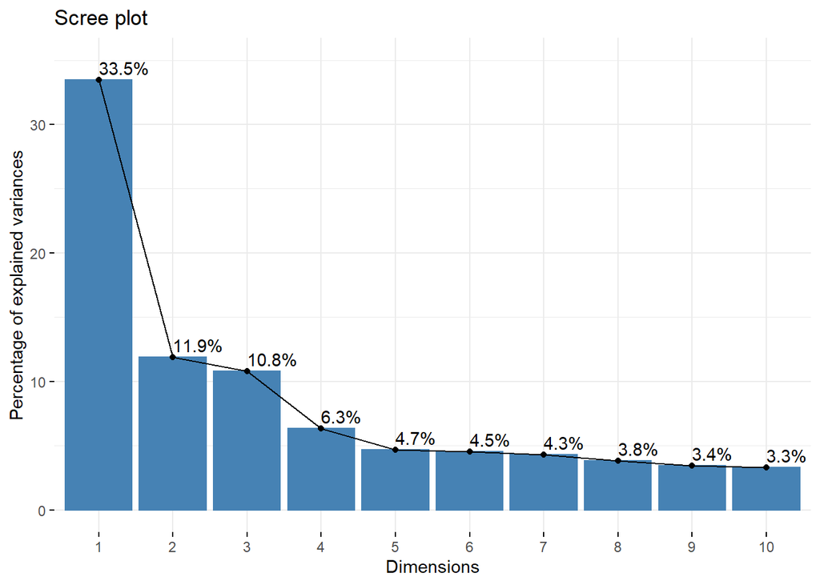

```r
#Visualisation des axes
fviz_screeplot (res.mca, addlabels = TRUE, ylim = c (0, 35))
```

```r
# Travaillons sur les variables
var <- get_mca_var(res.mca)
var$contrib
```

```
##                                             Dim 1       Dim 2        Dim 3
## PhoneService_No                      6.074249e-01 0.898790065 2.676434e+01
## PhoneService_Yes                     6.512558e-02 0.096364538 2.869561e+00
## MultipleLines_No                     8.981135e-01 2.101226936 1.209359e-03
## MultipleLines_No phone service       6.074249e-01 0.898790065 2.676434e+01
## MultipleLines_Yes                    4.081937e-01 1.197235671 6.329348e+00
## InternetService_DSL                  1.252689e+00 1.079680248 1.163808e+01
## InternetService_Fiber optic          1.661419e+00 0.727436006 9.693667e+00
## InternetService_No                   1.053461e+01 0.008824521 1.898241e-02
## OnlineSecurity_No                    1.976157e+00 3.570229998 3.274433e-01
## OnlineSecurity_No internet service   1.053461e+01 0.008824521 1.898241e-02
## OnlineSecurity_Yes                   9.436282e-01 6.598471471 4.012195e-01
## OnlineBackup_No                      1.691281e+00 3.671951949 1.489936e-01
## OnlineBackup_No internet service     1.053461e+01 0.008824521 1.898241e-02
## OnlineBackup_Yes                     1.223833e+00 4.995460532 2.963975e-01
## DeviceProtection_No                  1.700733e+00 5.776667206 3.407493e-01
## DeviceProtection_No internet service 1.053461e+01 0.008824521 1.898241e-02
## DeviceProtection_Yes                 1.214628e+00 7.792566686 5.917231e-01
## TechSupport_No                       1.975467e+00 5.135486244 1.294875e-01
## TechSupport_No internet service      1.053461e+01 0.008824521 1.898241e-02
## TechSupport_Yes                      9.454641e-01 9.211921618 1.225083e-01
## StreamingTV_No                       1.482520e+00 3.908233126 2.326347e+00
## StreamingTV_No internet service      1.053461e+01 0.008824521 1.898241e-02
## StreamingTV_Yes                      1.431351e+00 4.346038076 2.747068e+00
## StreamingMovies_No                   1.379938e+00 4.222239846 2.412709e+00
## StreamingMovies_No internet service  1.044656e+01 0.009870526 1.940769e-02
## StreamingMovies_Yes                  1.475826e+00 4.262511151 2.583863e+00
## Month-to-month                       3.792254e-01 8.592186270 2.901425e-04
## One year                             2.088102e-02 1.938567699 1.319902e-03
## Two year                             6.402337e-01 9.949438957 3.551124e-03
## Bank transfer (automatic)            1.273355e-04 2.067653055 5.138802e-02
## Credit card (automatic)              6.066681e-04 2.805092672 2.214319e-04
## Electronic check                     9.916881e-01 3.504195327 1.082046e+00
## Mailed check                         1.371772e+00 0.588746937 2.238833e+00
##                                            Dim 4       Dim 5
## PhoneService_No                      12.30478643  0.13087975
## PhoneService_Yes                      1.31926809  0.01403238
## MultipleLines_No                      5.11604716  4.61811155
## MultipleLines_No phone service       12.30478643  0.13087975
## MultipleLines_Yes                     0.54089043  4.50367691
```

[output cut: 13 more lines]

```
## TechSupport_No internet service       0.25404039  0.01775466
## TechSupport_Yes                       3.68566574  0.06154891
## StreamingTV_No                        8.33925819  0.91371662
## StreamingTV_No internet service       0.25404039  0.01775466
## StreamingTV_Yes                       6.57294035  1.15335693
## StreamingMovies_No                    8.26089875  0.99946146
## StreamingMovies_No internet service   0.25627961  0.02097437
## StreamingMovies_Yes                   5.84664197  1.15509609
## Month-to-month                        0.65071752  1.63456032
## One year                              0.32340012 49.93265996
## Two year                              0.48403311 21.37980221
## Bank transfer (automatic)             0.60315731  7.47791841
## Credit card (automatic)               1.01072009  0.07601031
## Electronic check                      7.51384560  0.18076010
## Mailed check                          2.50667030  3.58501647
```

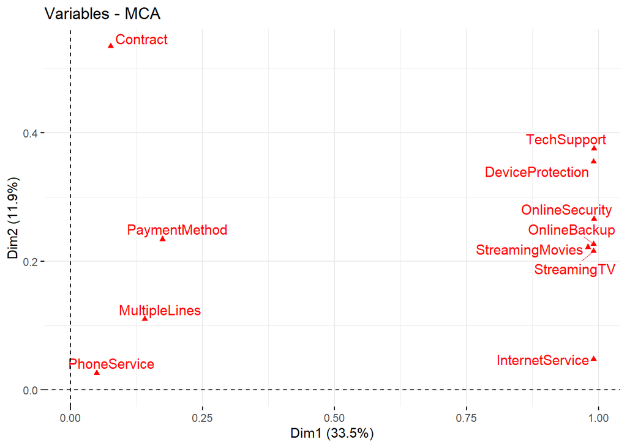

```r
#Correlation entre les variables et les axes... En rouge les variables actives et en bleu les illustratives
fviz_mca_var (res.mca, choice = "mca.cor",repel = TRUE)
```

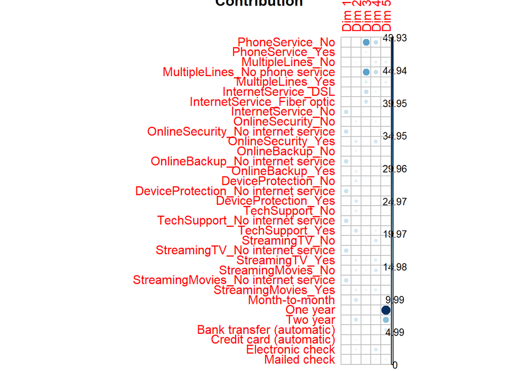

```r
#contrib graph (des modalit?s)
corrplot(var$contrib, is.corr=FALSE,main="Contribution")
```

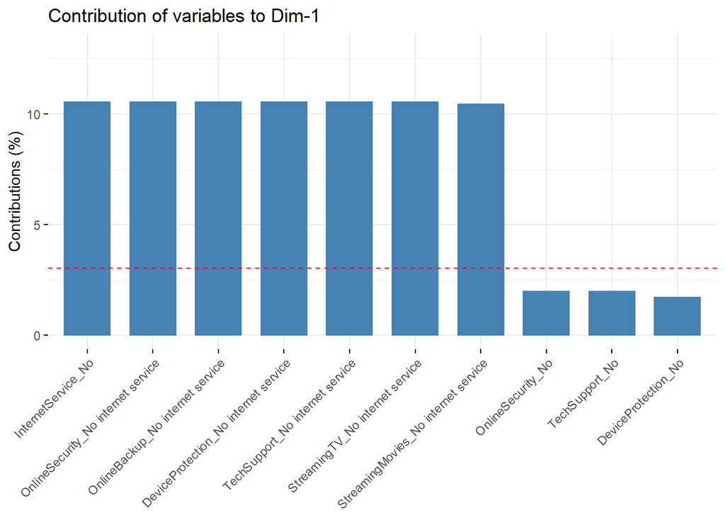

```r
fviz_contrib(res.mca, choice = "var", axes = 1, top = 10, ylim = c (0, 13))  #histo par axe
```

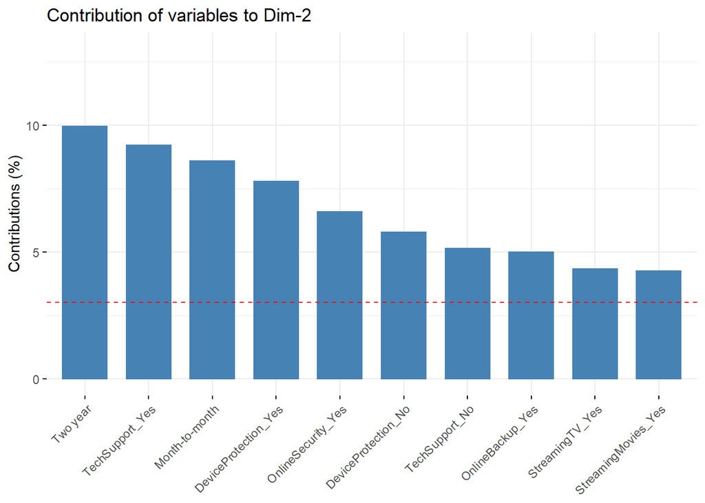

```r
fviz_contrib(res.mca, choice = "var", axes = 2, top = 10, ylim = c (0, 13))
```